# 22100 - R for Bio Data Science

## Presentation outline

- Introduction to the data set
- Data cleaning
- Augmenting
- Results
- Discussion
- Conclusion

## The dataset

- Study with 418 participants all suffering from PBC (varying stages of disease severity) conducted by the Mayo Clinic between 1974 and 1984
- Clinical trial in Primary Biliary Cirrhosis (PBC) with 312 participants
- Randomized, placebo-controlled clinical trial with the drug D-penicillamine

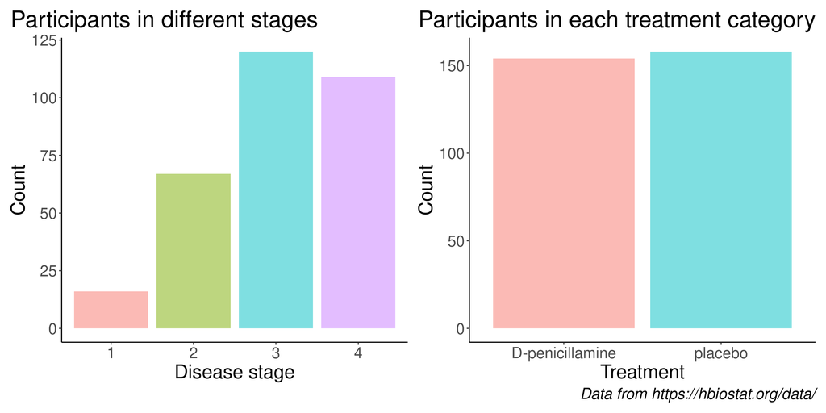

## Variables in the dataset

- 19 variables
- Demographic characteristics: age and gender
- Various physiological measurements e.g. serum bilirubin, albumin, protrombin time and presence of edema
- Variables related to the trial: drug/placebo, status (dead/alive), number of follow-up days (until death or end of study participation)

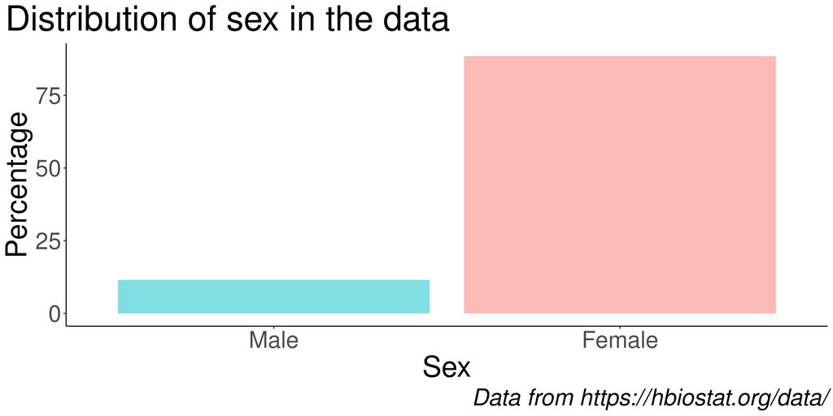

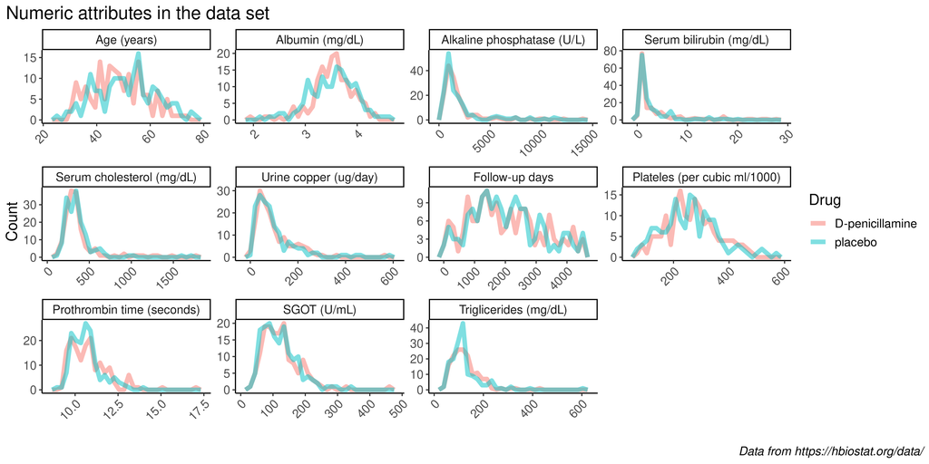

## Data wrangling

- Removing non-trial participants
- Imputing NA values
- Rounding off variables

## Table of missing values

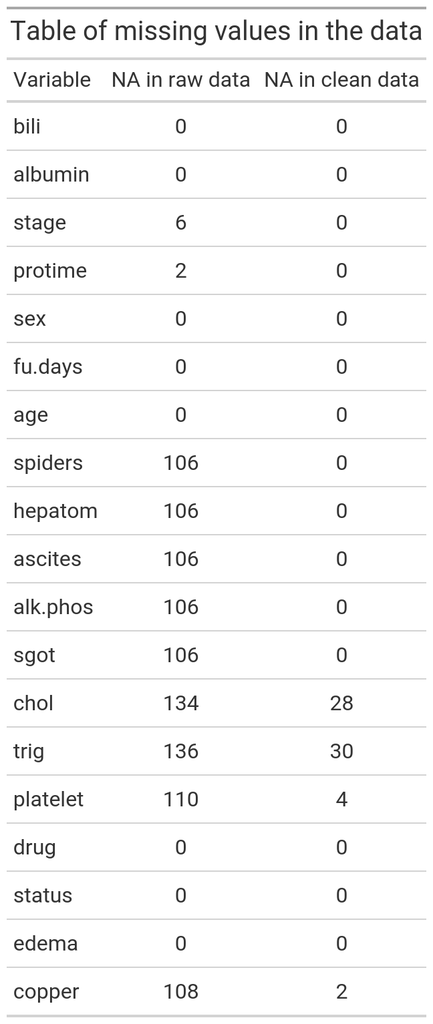

## Augmenting

- Created column with edema score
- Split up edema column
- Calculating Mayo risk score

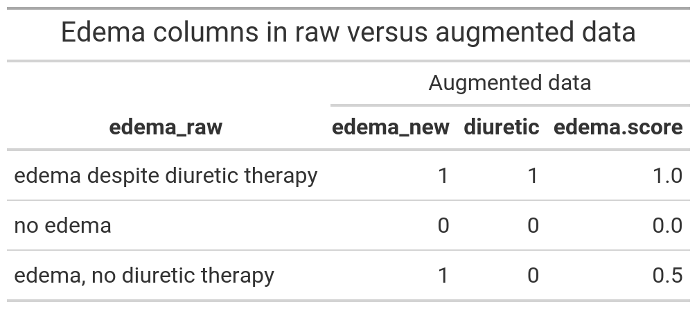

## Mayo risk score

Formula \[ \small \text{Mayo risk score} = 0.04 \cdot \text{age in years} + 10.87 \cdot log(\text{serum bilirubin in mg/dL}) \\ \small - 22.53 \cdot log(\text{serum albumin in gm/dL}) + 12.38 \cdot log(\text{prothrombin time in seconds}) \\ \small + 10.86 \cdot \text{edema score} \]

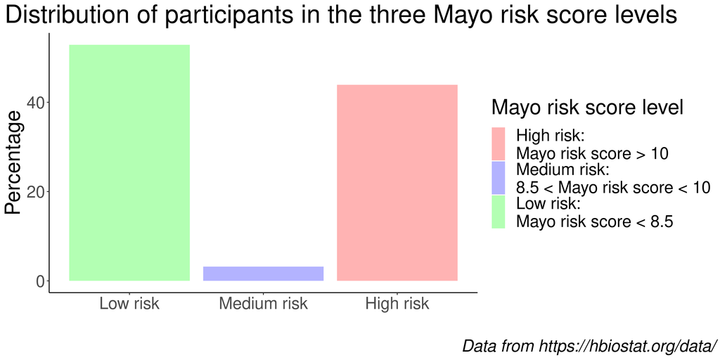

## Results

## Scatter plot of bilirubin

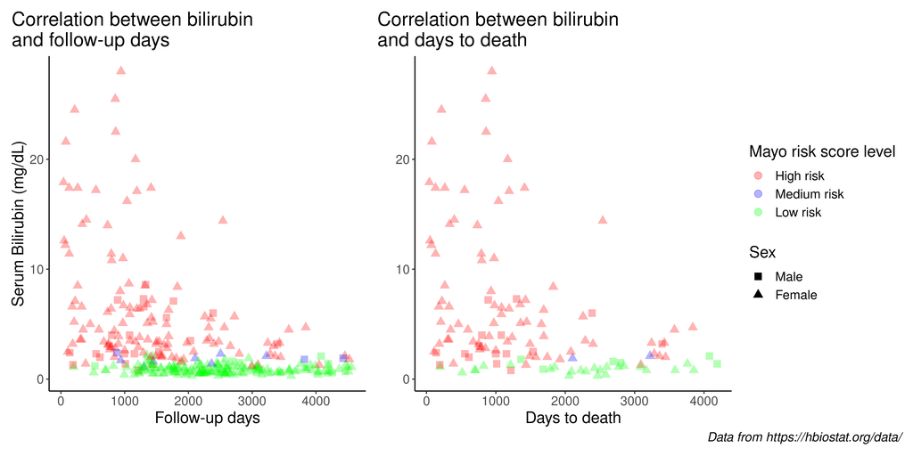

## Follow-up days in relation to stage

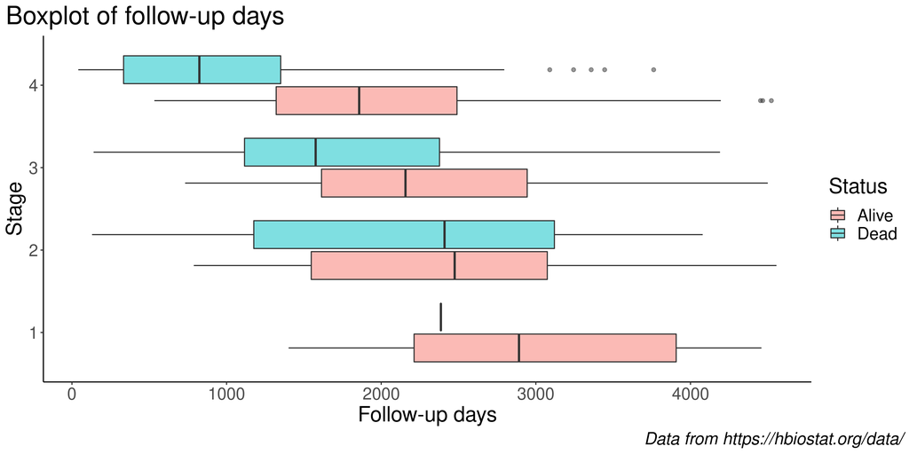

## Drug

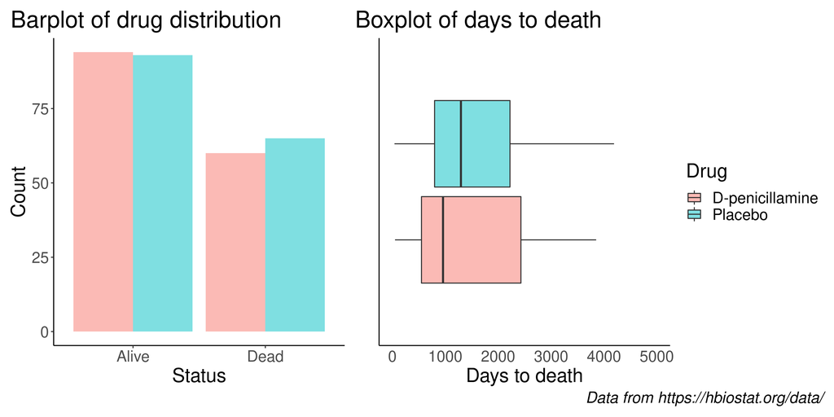

## Principal Component Analysis

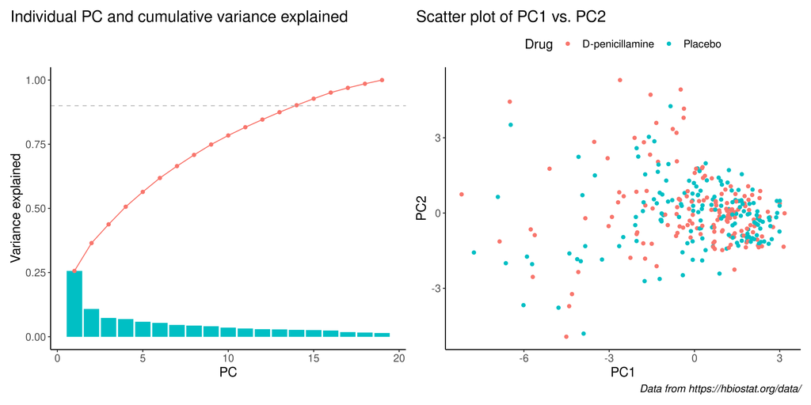

## Logistic Regression

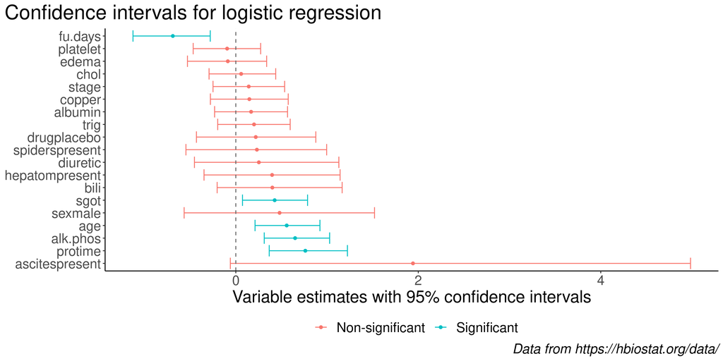

## Clustering variance

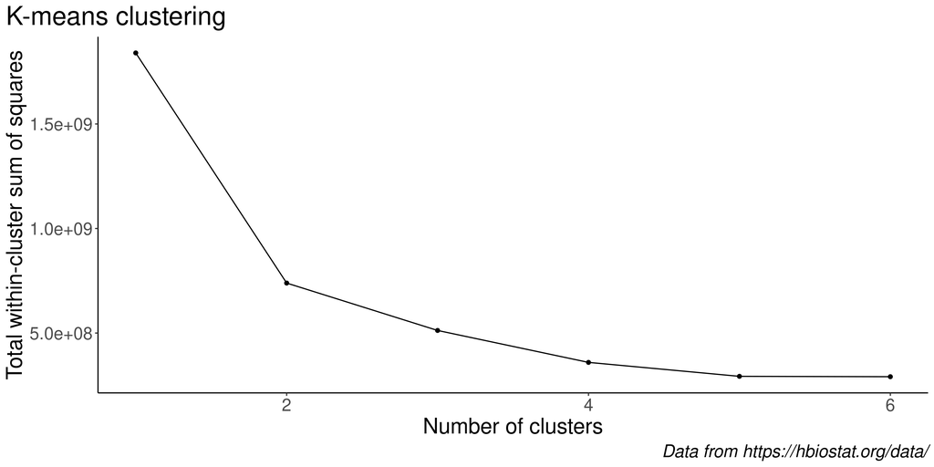

## Clustering 1-4 clusters

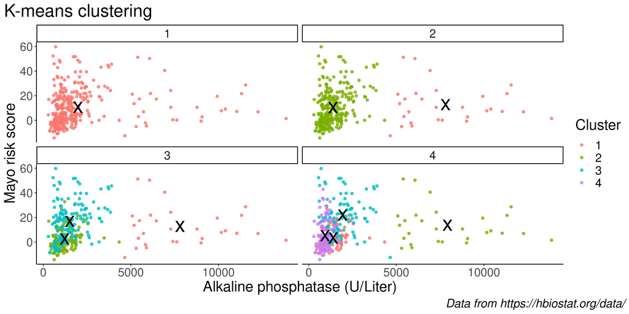

## Discussion and conclusion

- Follow-up days
- The intervals for mayo risk score
- Physiological variables
- Is the drug usable?